# RSV (AREXVY) - Immunisation reaction

OpenSourcePV

Data Lock Point: Data contains VAERS reports processed as of 2023_12_29 (Year_Month_Day). Flag NEW was defined against reports processed as of 2023_11_24.

# 1 Quantitative Signal status

## 1.1 Disproportionality

The vaccine-event combination “RSV (AREXVY) - Immunisation reaction” was **a signal of disproportionate reporting** with an EB05 value of 2.07.

The threshold for being flagged as a signal of disproportionate reporting is an EB05>=2 meaning that there there is a 95% probability that the reporting of Immunisation reaction was at least twice post exposure to RSV (AREXVY) than post all vaccines [1]. Under the assumption of no causality between RSV (AREXVY) and Immunisation reaction and no bias it would have been expected to observe an EBGM of 1.

It means that the quantified causality criterion of strength of association is **met**.

*It is to be noted that the nature of the spontaneous report does not provide reliable estimates of the strength of association (whatever the choice of the disproportionality method) and that some reporting bias or difference in demographic characteristics might explain the (un)observed disproportion*.

## 1.2 Time-to-onset

The vaccine-event combination “RSV (AREXVY) - Immunisation reaction” was **not a signal of unexpected time-to-onset distribution** with a p-value of the two-sample Kolmogorov-Smirnov test being 0.9108506 and distance between the two empirical cumulative distributions being of 16.2688442%.

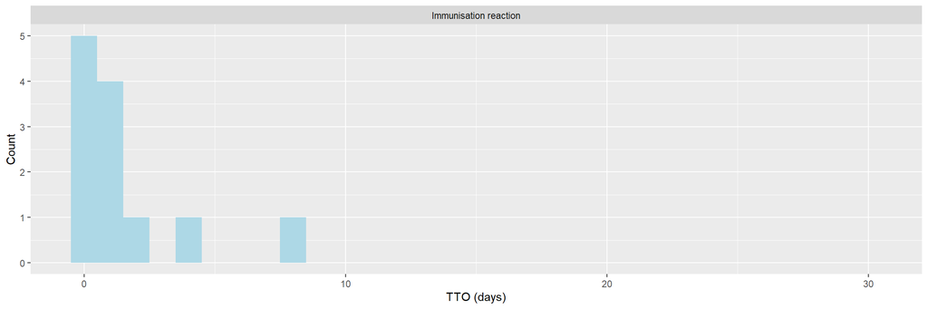

The TTO signal detection method tests if the distribution of Immunisation reaction post RSV (AREXVY) is significantly different from the distribution of Immunisation reaction post other vaccines using a two-sample Kolmogorov-Smirnov test [2]. The threshold for being flagged as a signal of unexpected time-to-onset distribution is a P-value <0.001 and a distance between the two empirical distributions larger than 20%. Under the assumption of no causality and no bias, it would have been expected that the time-to-onset distribution for “Immunisation reaction” would have been the same post RSV (AREXVY) than post other vaccines.

It means that the quantified causality criterion of temporality is **not met**.

*It is to be noted that the nature of the spontaneous report does not provide reliable estimates of the temporal relationship between the exposure and the occurrence of the events as there is the reporting bias over time: the latter the event occurs after exposure, the less chance it has to be reported. Other biases could distort the reported time-to-onset distribution (media attention, etc.)*

## 1.3 Overall

Based on the screening of the Empirical Bayes Geometric Mean (EBGM) and the screening of the time-to-onset distribution,the vaccine-event combination “RSV (AREXVY) - Immunisation reaction” is **considered as quantitative signal**.

# 2 Signal History

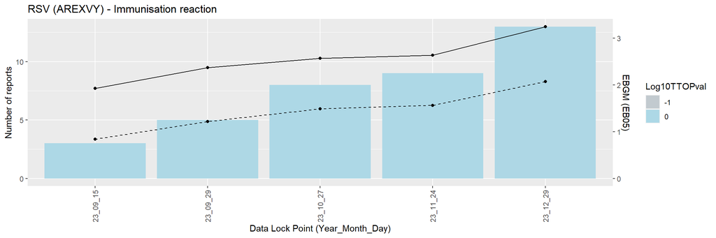

# 3 Case series

## 3.1 Seriousness

A total of 13 reports of Immunisation reaction were received post exposure to RSV (AREXVY). Among them:

- 0 (0.0 %) were fatal cases.
- 1 (7.7 %) were life threatening cases.
- 2 (15.4 %) were hospitalized cases.
- 0 (0.0 %) were emergency room cases.
- 0 (0.0 %) were cases with disabilies.

4 new cases were received since last data refresh.

## 3.2 Demographic characteristics

13 cases of Immunisation reaction post RSV (AREXVY) were reported in VAERS:

- Among them, there were 10 (76.9%) female cases and 2 (15.4%) male cases while the overall female:male ratio is 68:26%.
- The mean (median) age for patients presenting symptoms of Immunisation reaction was 76 (74) years while the overall mean (median) age was 71 (71) years.
- The top 5 contributing US states for patients presenting symptoms of Immunisation reaction were OH ( 15.4 %) , WI ( 15.4 %) , AZ ( 7.7 %) , CA ( 7.7 %) , FL ( 7.7 %) while overall the top 5 of contributing US states are NA ( 11.9 %) , FL ( 9.2 %) , CA ( 8.4 %) , NY ( 5.7 %) , TX ( 4.5 %)

# 4 Listing of the cases

Narratives can be made visible clicking on the ⊕ symbol.

|  | VAERS ID | Sex/Age (Years) | Receipt Date | Seriousness status | List of symptoms | New | SYMPTOM_TEXT |
| --- | --- | --- | --- | --- | --- | --- | --- |
| &oplus; | 2721363 | M/91 | 12/06/2023 | Life threatening &amp; Hospitalized | Abdominal pain, Acute kidney injury, ADAMTS13 activity increased, Back pain, Blood bilirubin increased, Blood creatinine increased, Dialysis, Immunisation reaction, Laboratory test normal, Plasmaphere… | Yes | on 10 27 2023 at 914 am patient presented to emergency room with back pain urinary retention and abdominal pain At that time platelet count was found to be decreased at 112000 creatinine was elevated … |
| &oplus; | 2721736 | F/80 | 12/07/2023 |  | Immunisation reaction | Yes | PATIENT RECIEVED AREXVY VACCINE ON 12 2 23 PATIENT REPORTED ADVERSE REACTION TO US ON 12 6 PATIENT STATES THEY WENT TO URGENT CARE FOR THE REACTION WHICH STARTED ON 12 3 23 AND WAS PRESCRIBED CEPHALEX… |
| &oplus; | 2722254 | F/77 | 12/08/2023 |  | Arthralgia, Back pain, Chills, Immunisation reaction, Injected limb mobility decreased, Injection site pain, Musculoskeletal pain, Pain, Pain in extremity, Pyrexia, Rotator cuff syndrome, Sacroiliitis… | Yes | She got her vaccines she went home Then later in teh afternoon her and her husband ran an errand and had an early dinner The RSV vaccine in the left arm gave her fever and chills and body aches for ab… |
| &oplus; | 2727139 | U/NA | 12/25/2023 |  | Immunisation reaction | Yes | Hospitalized This serious case was reported by a consumer via interactive digital media and described the occurrence of hospitalization in a patient who received RSVPreF3 adjuvanted Arexvy for prophyl… |
| &oplus; | 2675065 | F/65 | 08/22/2023 |  | Immunisation reaction, Injection site bruising, Injection site erythema, Injection site pain, Injection site pruritus, Injection site swelling, Local reaction | No | The patient came to the pharmacy 8 17 23 for 2 vaccines the Influenza Fluzone HD and the RSV vaccine Arexvy The pharmacist administered the two vaccines in the right arm of patient After the injection… |
| &oplus; | 2682039 | F/75 | 09/14/2023 |  | Bronchial hyperreactivity, Immunisation reaction | No | Patient states they were seen by their primary care physician and diagnosed with reactive airway disease as a result of this RSV |
| &oplus; | 2682059 | F/70 | 09/14/2023 |  | Chills, Chromaturia, Culture urine positive, Haematuria, Headache, Immunisation reaction, Insomnia, Lower urinary tract symptoms, Micturition urgency, Nausea, Nocturia, Pain in extremity, Protein urin… | No | Had vaccine about 1015 amabout an hour after I developed a headachearm began to get sorenothing unusual thenAs the night progressedheadache became worse and had chillsslight nauseaCouldnt sleep had to… |
| &oplus; | 2682823 | F/68 | 09/16/2023 |  | Immunisation reaction, Rash pruritic, Urticaria | No | Customer said that early in the morning she woke up with an itchy rash hives across her belly She called the dr who suspected it was a reaction to the Arexvy The rash cleared up by the next day and sh… |
| &oplus; | 2683375 | F/69 | 09/18/2023 |  | Immunisation reaction, Injection site erythema, Injection site warmth | No | inch to an inch and a half wide red spot on the injection site Red and hot to the touch per patient Recommened the patient go to the doctor to check for cellulitis The patient went in today and after … |
| &oplus; | 2689586 | F/73 | 10/02/2023 |  | Asthenia, Chills, Diarrhoea, Fatigue, Feeling abnormal, Headache, Immunisation reaction, Influenza virus test negative, Malaise, Nausea, Pain, SARS-CoV-2 test negative | No | 9 19 330pm Severe chills shivering for 5 hours Took 2 advil Sleep 849 hrs 9 20 430pm chills shivering for 4 hrs Covid antigen test at pharmacy negative 9 21 330am woke up nauseous but didn t throw up … |

[output cut: 3 more lines]

# 5 Disclaimer

This analysis is exploratory only and authors cannot be held responsible for any decision made using these data. It is important to distinguish quantitative signals such as disproportionate reporting, unexpected time-to-onset patterns or cluster from safety signals. Only a qualitative review using multiple data source (literature, clinical trials, etc.) and multiple causality criteria assessment could qualify quantitative signals into safety signals.

# 6 References

[1] Dumouchel W. Bayesian data mining in large frequency tables, with an application to the FDA spontaneous reporting system. Am Stat 1999; 53: 177–190.

[2] Van Holle L et al, Using time‐to‐onset for detecting safety signals in spontaneous reports of adverse events following immunization: a proof-of-concept study. Pharmacoepidemiology and Drug Safety 21 (6), 603-610.